# Automated Model training: Binary classification

Team Data Science Process by Microsoft

October 19, 2016

## 0.2 Specify YAML parameter file for input data and modeling

Specify the file which contins the parameter set to train the ML models with. If there are multiple values for each parameter file, then modes ML algorithms will be run with a specified number of random combination of these parameters (currently set to 59).

```
## [1] "Yaml file loc: F:\\Azure-TDSP-Utilities\\DataScienceUtilities\\Modeling\\BinaryClassification\\YamlFiles\\BinaryClassification_UCI_Income.yaml"
```

## 0.3 Input data, and splitting data into train/test

Once the data is read in, it is split into training and testing. Modeling is run on training data (using CV/bootstrapping and parameter sweeping), and evaluated on the test data.

```
## [1] "Input data description: UCI Adult Census & Income Binary Classification Dataset"
```

```
## [1] "Train/test split percent: 0.75"
```

```
##   income age    type_employer fnlwgt education education_num
## 1     X0  39        State.gov  77516 Bachelors            13
## 2     X0  50 Self.emp.not.inc  83311 Bachelors            13
## 3     X0  38          Private 215646   HS.grad             9
##              marital        occupation  relationship  race  sex
## 1      Never.married      Adm.clerical Not.in.family White Male
## 2 Married.civ.spouse   Exec.managerial       Husband White Male
## 3           Divorced Handlers.cleaners Not.in.family White Male
##   capital_gain capital_loss hr_per_week country
## 1         2174            0          40 Vietnam
## 2            0            0          13 Vietnam
## 3            0            0          40 Vietnam
```

## 0.4 Model training

### 0.4.1 Define hyper-parameter sets for glmnet, randomForest and xgBoost

Create the control object for cross validation and parameter sweeping. Here we can use [OneSE](http://www.inside-r.org/packages/cran/caret/docs/oneSE) (one standard error) as selection function. By default, Caret’s train uses ‘best’ model, i.e. the tuning parameters associated with the largest (or lowest for “RMSE”) performance. oneSE is a rule in the spirit of the “one standard error” rule of Breiman et al. (1984), who suggest that the tuning parameter associated with the best performance may over fit. They suggest that the simplest model within one standard error of the empirically optimal model is the better choice.  
Also, for hyper-parameter sweeping, within a fixed computational time, selecting a random set of parameters (or ‘random’ search option) is typically a better choise than entire grid search for identifying parameter-set that will provide an optimal model, [Bergstra and Bengio, 2012](http://www.jmlr.org/papers/volume13/bergstra12a/bergstra12a.pdf). Therefore, we use a 59 point random grid sample of hyper-parameters. Choosing 59 random points from a hyper-parameter grid will guarantee with 95% confidence that one of the hyper-parameter set will provide a model with accuracy that is within top 5% of the accuracy of all the grid hyper-parameters.

### 0.4.2 Define train formula based on target and features in parameters file

```
## income ~ age + type_employer + fnlwgt + education + education_num +
##     marital + occupation + relationship + race + sex + capital_gain +
##     capital_loss + hr_per_week + country
```

### 0.4.3 Train glmnet, randomForest, and xgBoost with parameter sweeping

```
## [1] "Train GlmNet Model: TRUE"
```

```
## [1] "Train RandomForest Model: TRUE"
```

```
## [1] "Train xgBoost Model: TRUE"
```

## 0.5 Model evaluation: Compare model accuracies of different algorithms, and examine variable importance

### 0.5.1 Plot accuracy in test data vs. alogrithms

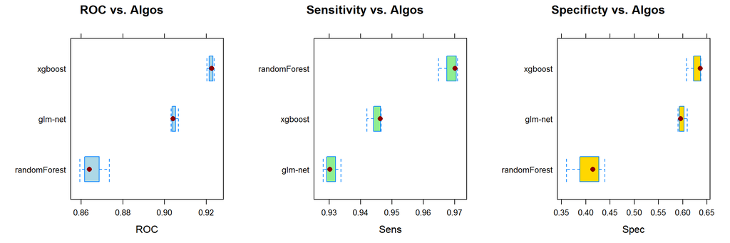

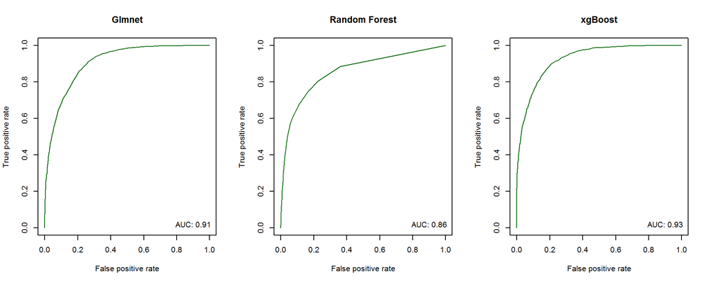

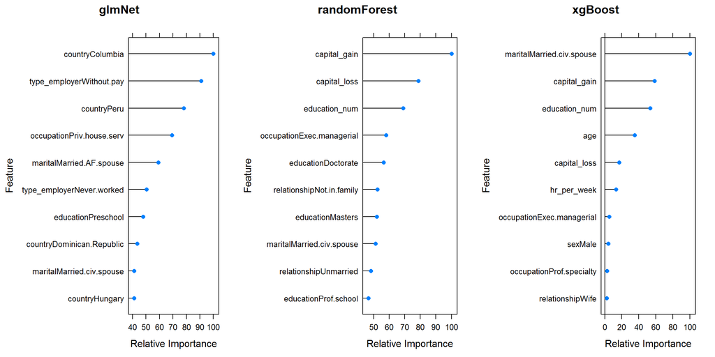

## 0.6 Summary

Here we perform preliminary exploration of 3 algorithms with limited CV and parameter grid sweeping and compare the accuracy of the models in the test data. Based on these explorations, user may decide to use a limited number of algorithms for creating models with extensive parameters sweeping and evaluating those models in the test data-set. Users may modify the code to explore according to the needs of their data-sets or based on their experience with [other algorithms](https://topepo.github.io/caret/modelList.html) available for use through Caret. The top 2-3 approaches could be taken for further model development and testing using the test data-set. Also, there are many alternative ways to run the algorithms, besides caret, and compare the results.